## Analysis of NYC Taxi Data

In this section, we study 10,000 random samples from our 100,000 sample records file. We haven’t applied Bootstrap techniques in here for simplicity. The bootstrap method is applied to the next section where the modeling is performed.

```r
filename  <- "sampledData100000.csv";
Dat100000 <- read.csv(filename);
records     <- Dat100000[sample(1:nrow(Dat100000), 10000, replace=FALSE),]

if (!require(e1071)) install.packages('e1071')
library(e1071)

if (!require(lubridate)) install.packages('lubridate')
library(lubridate)

if (!require(geosphere)) install.packages('geosphere')
library(geosphere)
```

1.a) What is the distribution of a number of passengers per trip?

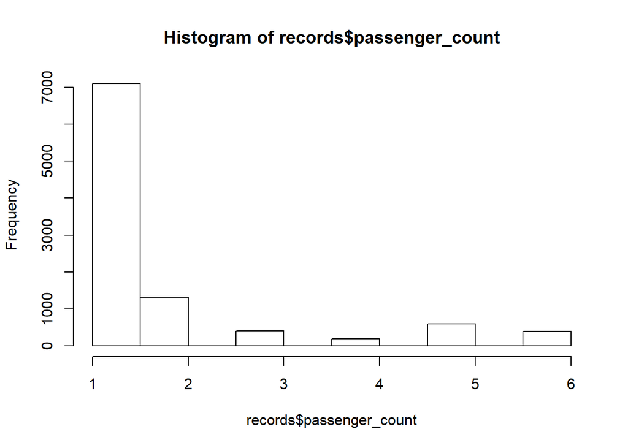

```r
hist(records$passenger_count)
```

```r
summary(records$passenger_count)
```

```
##    Min. 1st Qu.  Median    Mean 3rd Qu.    Max.
##   1.000   1.000   1.000   1.706   2.000   6.000
```

```r
skewness(records$passenger_count)
```

```
## [1] 2.022238
```

2. What is the distribution of payment_type?

Payment type is a discrete variable.

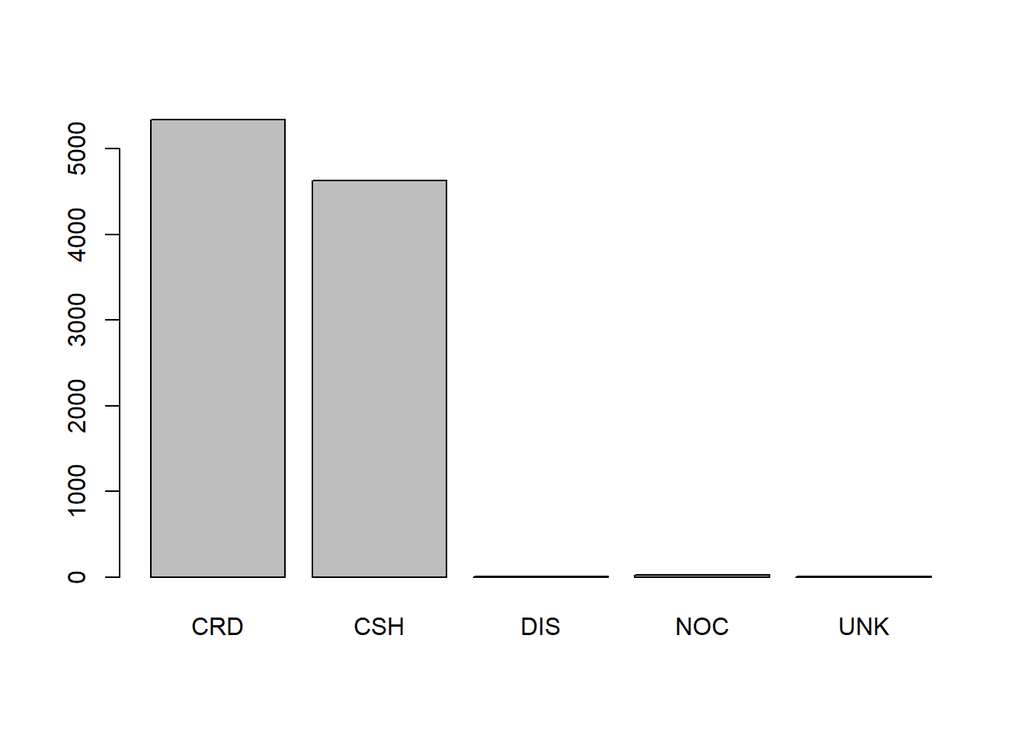

```r
barplot(table(records$payment_type))
```

Note: CRD - Card, CSH - Cash Most of the transactions are either by card or cash.

1.c) What is the distribution of fare amount?

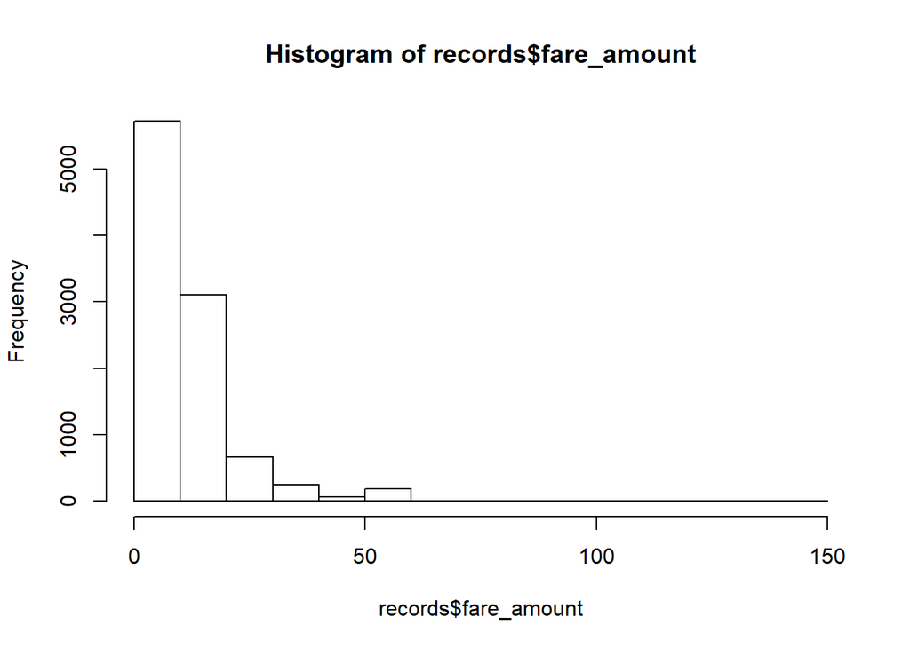

```r
hist(records$fare_amount)
```

```r
summary(records$fare_amount)
```

```
##    Min. 1st Qu.  Median    Mean 3rd Qu.    Max.
##    2.50    6.50    9.00   12.16   14.00  150.00
```

```r
skewness(records$fare_amount)
```

```
## [1] 3.401511
```

1.d) What is the distribution of tip amount?

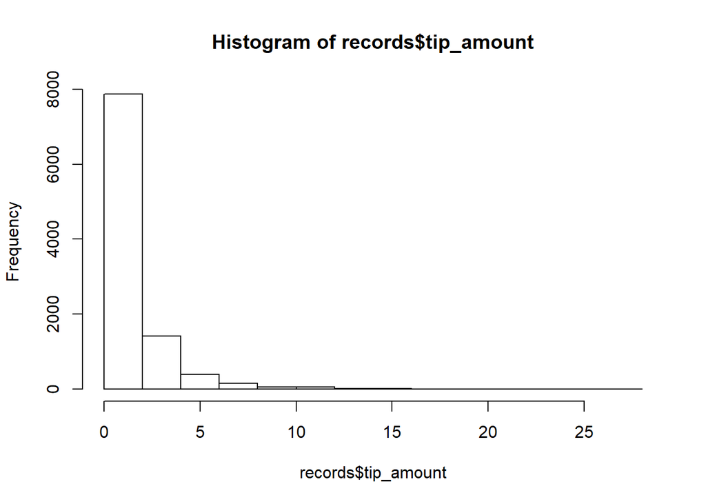

```r
hist(records$tip_amount)
```

```r
summary(records$tip_amount)
```

```
##    Min. 1st Qu.  Median    Mean 3rd Qu.    Max.
##   0.000   0.000   1.000   1.318   2.000  26.200
```

```r
skewness(records$tip_amount)
```

```
## [1] 3.031808
```

1.e) What is the distribution of total amount?

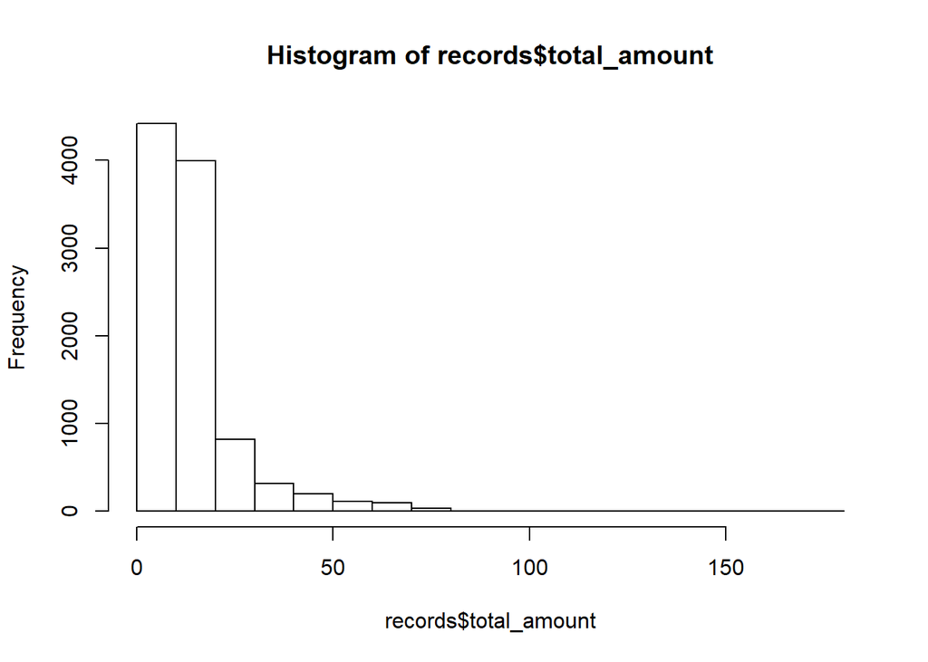

```r
hist(records$total_amount)
```

```r
summary(records$total_amount)
```

```
##    Min. 1st Qu.  Median    Mean 3rd Qu.    Max.
##    3.00    8.00   11.00   14.54   16.50  176.03
```

```r
skewness(records$total_amount)
```

```
## [1] 3.375049
```

1.f) What are top 5 busiest hours of the day?

It seems to be each day is different. We plot the busiest hour of each day.

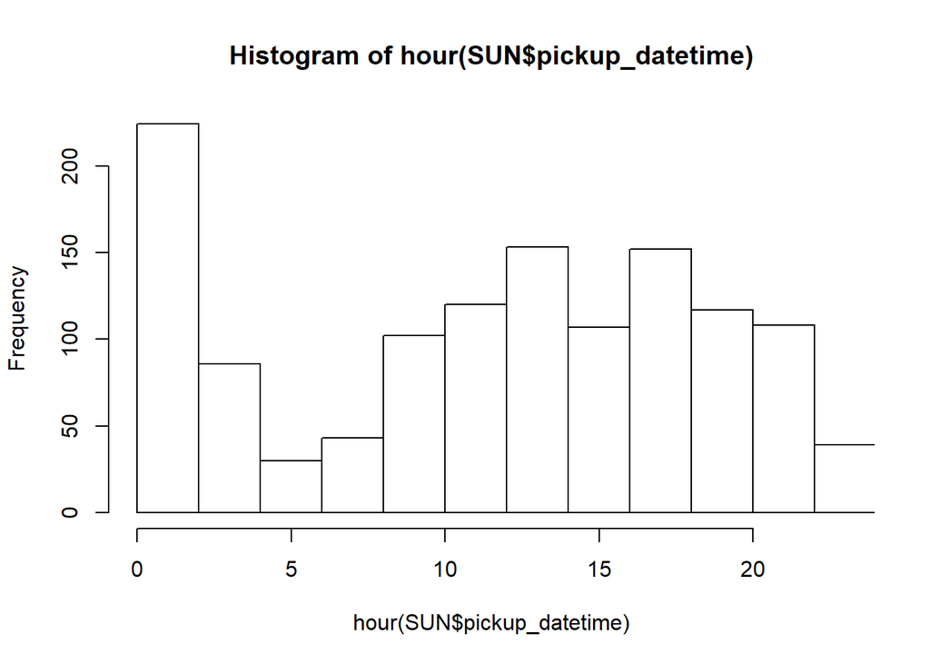

```r
records$pickup_datetime_transformed <- ymd_hms(records$pickup_datetime)

SUN <- records[wday(records$pickup_datetime_transformed) == 1,]
MON <- records[wday(records$pickup_datetime_transformed) == 2,]
TUE <- records[wday(records$pickup_datetime_transformed) == 3,]
WED <- records[wday(records$pickup_datetime_transformed) == 4,]
THU <- records[wday(records$pickup_datetime_transformed) == 5,]
FRI <- records[wday(records$pickup_datetime_transformed) == 6,]
SAT <- records[wday(records$pickup_datetime_transformed) == 7,]

#SUNDAY
hist(hour(SUN$pickup_datetime),xlim = c(0, 23))
```

```r
freqArraySun <- c(hour(SUN$pickup_datetime))
names(sort(summary(as.factor(freqArraySun)), decreasing=T)[1:5])
```

```
## [1] "18" "1"  "13" "0"  "14"
```

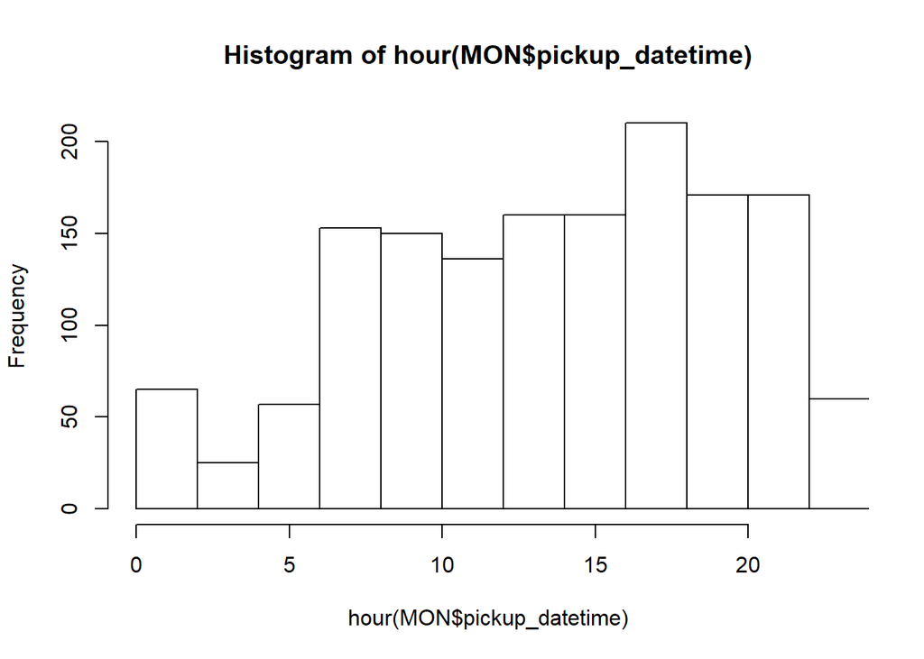

```r
# MONDAY
hist(hour(MON$pickup_datetime),xlim = c(0, 23))
```

```r
freqArrayMon <- c(hour(MON$pickup_datetime))
names(sort(summary(as.factor(freqArrayMon)), decreasing=T)[1:5])
```

```
## [1] "18" "21" "19" "8"  "17"
```

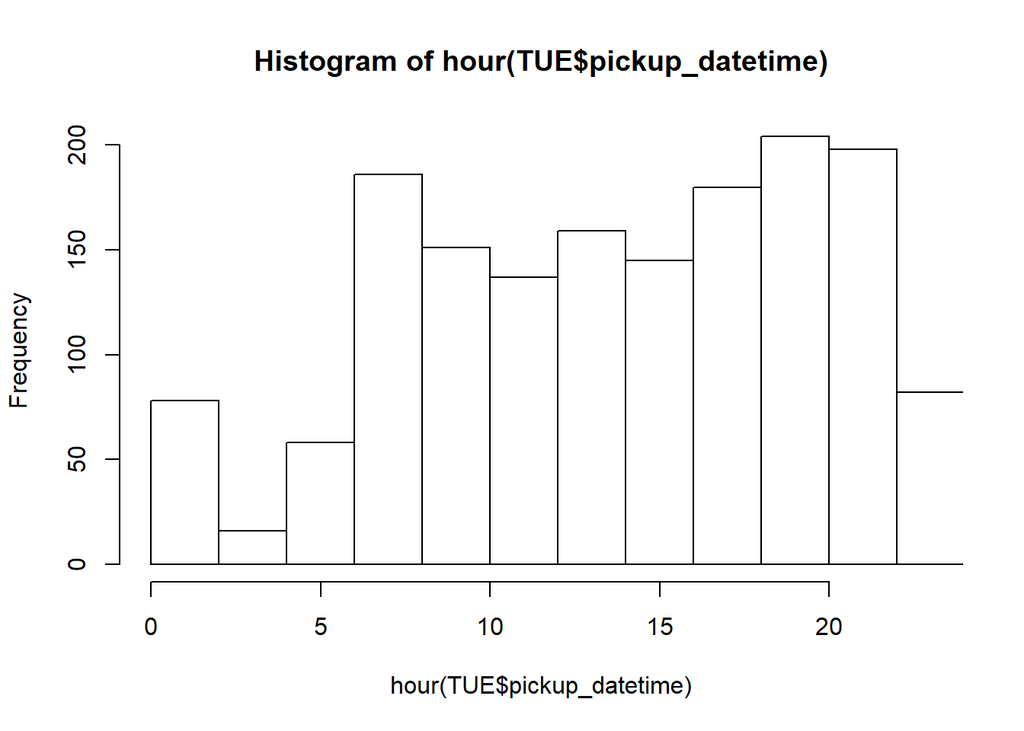

```r
# TUESDAY
hist(hour(TUE$pickup_datetime),xlim = c(0, 23))
```

```r
freqArrayTue <- c(hour(TUE$pickup_datetime))
names(sort(summary(as.factor(freqArrayTue)), decreasing=T)[1:5])
```

```
## [1] "8"  "19" "20" "21" "22"
```

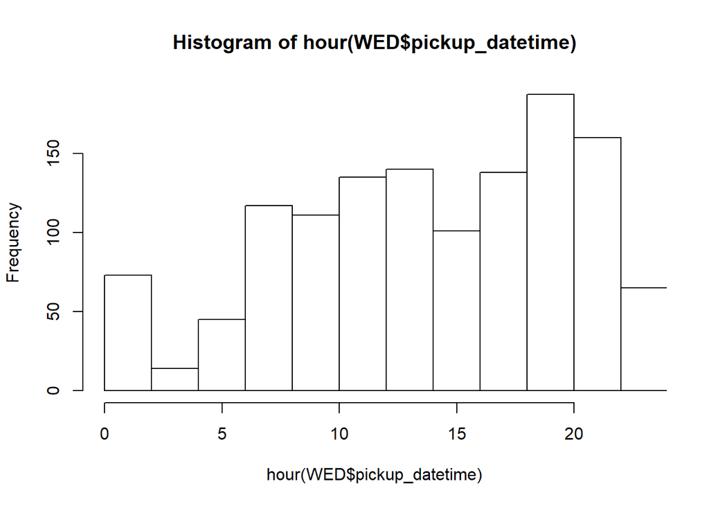

```r
# WEDNESDAY
hist(hour(WED$pickup_datetime),xlim = c(0, 23))
```

```r
freqArrayWed <- c(hour(WED$pickup_datetime))
names(sort(summary(as.factor(freqArrayWed)), decreasing=T)[1:5])
```

```
## [1] "20" "19" "22" "21" "18"
```

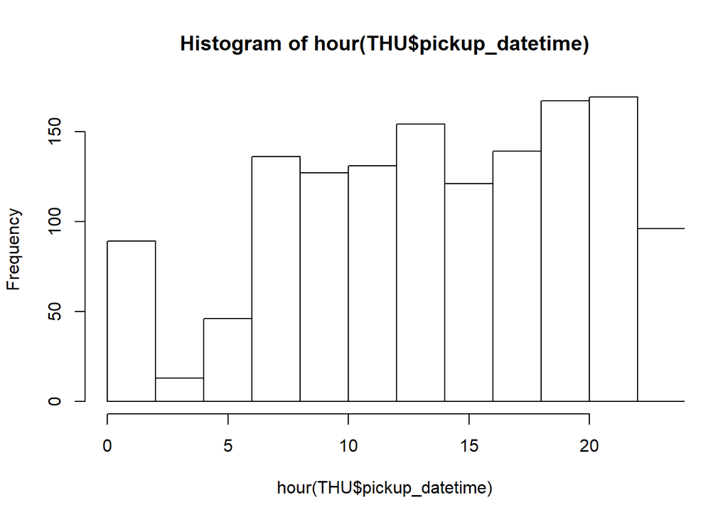

```r
# THURSDAY
hist(hour(THU$pickup_datetime),xlim = c(0, 23))
```

```r
freqArrayThu <- c(hour(THU$pickup_datetime))
names(sort(summary(as.factor(freqArrayThu)), decreasing=T)[1:5])
```

```
## [1] "23" "19" "22" "8"  "21"
```

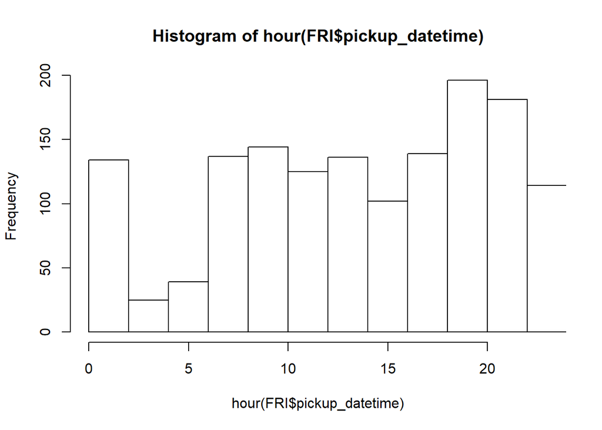

```r
# FRIDAY
hist(hour(FRI$pickup_datetime),xlim = c(0, 23))
```

```r
freqArrayFri <- c(hour(FRI$pickup_datetime))
names(sort(summary(as.factor(freqArrayFri)), decreasing=T)[1:5])
```

```
## [1] "23" "19" "20" "22" "21"
```

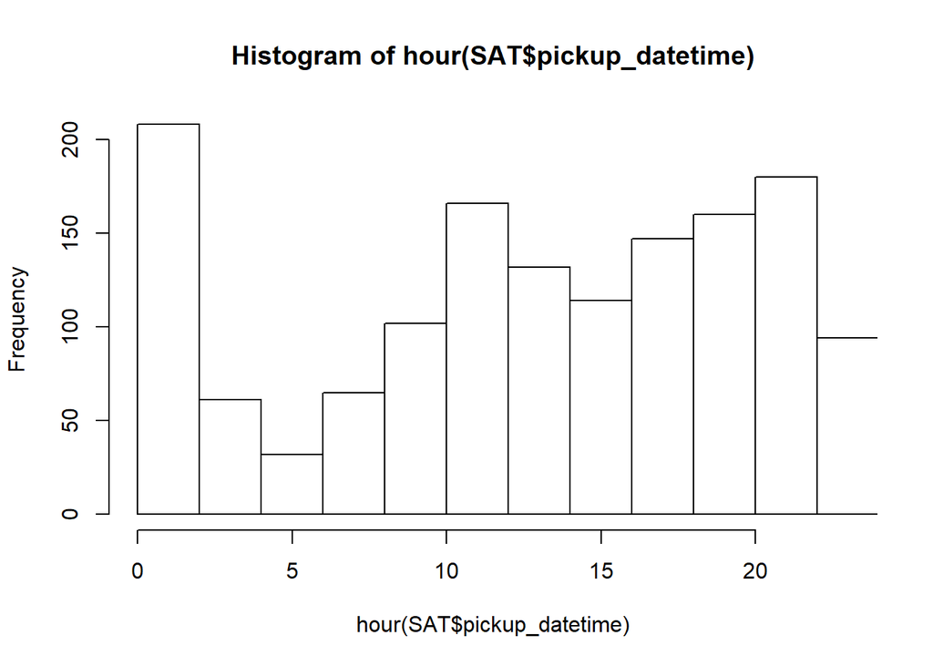

```r
# SATURDAY
hist(hour(SAT$pickup_datetime),xlim = c(0,23))
```

```r
freqArraySat <- c(hour(SAT$pickup_datetime))
names(sort(summary(as.factor(freqArraySat)), decreasing=T)[1:5])
```

```
## [1] "22" "23" "18" "19" "11"
```

1.g) What are the top 10 busiest locations of the city?

To find this we perform K-mean clustering on pickup locations with 10 clusters. Then we identify the cluster centers as the busiest locations.

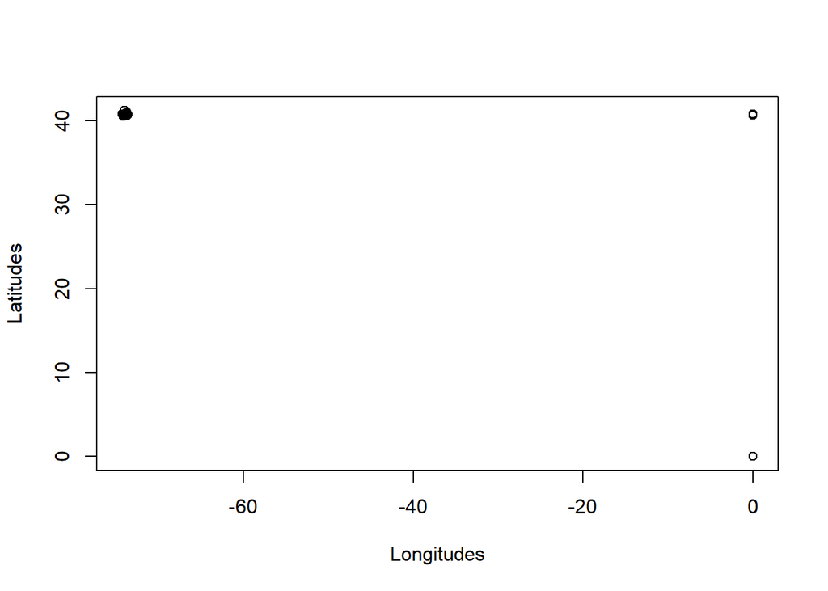

```r
# Let's clustering the GPS locations
pickLoc <- data.frame(pickLat=records$pickup_latitude,pickLon=records$pickup_longitude)
dropLoc <- data.frame(dropLat=records$dropoff_latitude,dropLon=records$dropoff_longitude)
pickLoc <- pickLoc[pickLoc$pickLat <= 90 & pickLoc$pickLat > -90, ]
pickLoc <- pickLoc[pickLoc$pickLon <= 180 & pickLoc$pickLon > -180, ]
dropLoc <- dropLoc[dropLoc$dropLat <= 90 & dropLoc$dropLat > -90, ]
dropLoc <- dropLoc[dropLoc$dropLon <= 180 & dropLoc$dropLon > -180, ]
x1 <- c(pickLoc$pickLon)
y1 <- c(pickLoc$pickLat)
x2 <- c(dropLoc$dropLon)
y2 <- c(dropLoc$dropLat)
x <- c(x1,x2)
y <- c(y1,y2)
gpsCordinates <- cbind(x,y)
plot(gpsCordinates, xlab="Longitudes", ylab="Latitudes")
```

I have just noticed some GPS points are zeros which are false. Some GPS locations are not in NYC. They have to be cleaned (outliers). To accurately clustering, we have to focus more on the high-density area

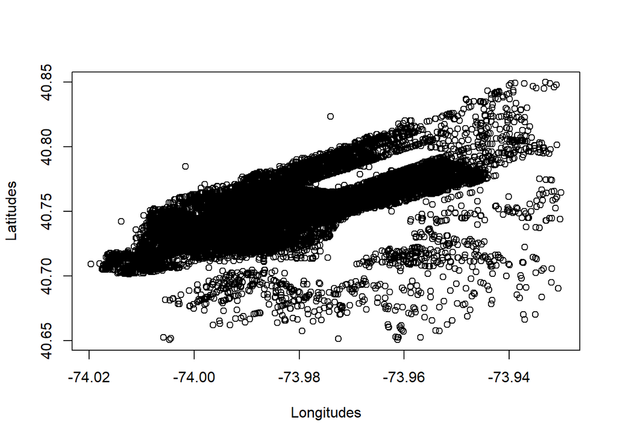

```r
pickLoc <- data.frame(pickLat=records$pickup_latitude,pickLon=records$pickup_longitude)
dropLoc <- data.frame(dropLat=records$dropoff_latitude,dropLon=records$dropoff_longitude)
pickLoc <- pickLoc[pickLoc$pickLat < 40.85 & pickLoc$pickLat > 40.65, ]
pickLoc <- pickLoc[pickLoc$pickLon < -73.93 & pickLoc$pickLon > -74.02, ]
dropLoc <- dropLoc[dropLoc$dropLat < 40.85 & dropLoc$dropLat > 40.65, ]
dropLoc <- dropLoc[dropLoc$dropLon < -73.93 & dropLoc$dropLon > -74.02, ]
x1 <- c(pickLoc$pickLon)
y1 <- c(pickLoc$pickLat)
x2 <- c(dropLoc$dropLon)
y2 <- c(dropLoc$dropLat)
x <- c(x1,x2)
y <- c(y1,y2)
gpsCordinates <- cbind(x,y)
plot(gpsCordinates, xlab="Longitudes", ylab="Latitudes")
```

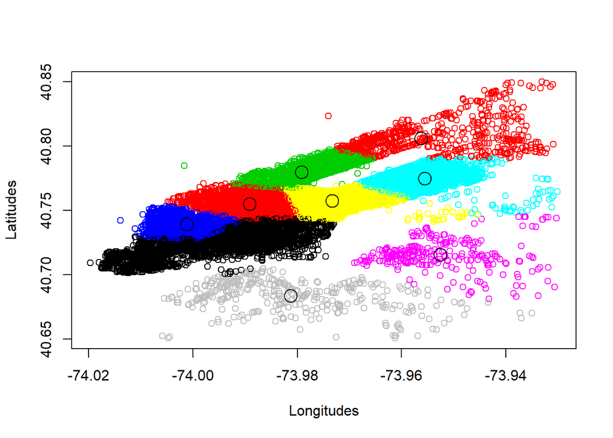

```r
# Since our data are cleaned, let's do the clustering now.
gpsCordinates <- cbind(x,y)
kc <- kmeans(gpsCordinates, 10)
plot(gpsCordinates, col=kc$cluster, xlab="Longitudes", ylab="Latitudes")
points(kc$centers,cex=2)
```

```r
# The GPS coordinates of the 10 busiest locations are
kc$centers
```

```
##            x        y
## 1  -73.98660 40.73206
## 2  -73.95627 40.80582
## 3  -73.97918 40.77961
## 4  -74.00126 40.73941
## 5  -73.95559 40.77465
## 6  -73.95260 40.71554
## 7  -73.97334 40.75722
## 8  -73.98125 40.68367
## 9  -74.00528 40.71673
## 10 -73.98915 40.75478
```

The above cluster centers are the busiest locations in NYC.

1.h) Which trip has the highest standard deviation of travel time?

To find this, I will find the trip having largest time difference to the mean of the travel time.

```r
travelTimeSD = (records$trip_time_in_secs - mean(records$trip_time_in_secs))^2

which.max(travelTimeSD)
```

```
## [1] 308
```

```r
records[which.max(travelTimeSD),]
```

```
##       record_id                        medallion
## 76187  11903065 D7A7BA0F3EBF2953C37AA457EBCDA941
##                           hack_license vendor_id rate_code
## 76187 47C318E319D38439DDF8DAB16469065F       CMT         2
##       store_and_fwd_flag     pickup_datetime    dropoff_datetime
## 76187                  N 2013-04-12 08:20:00 2013-04-12 09:47:00
##       passenger_count trip_time_in_secs trip_distance pickup_longitude
## 76187               2              5177          18.2         -73.7815
##       pickup_latitude dropoff_longitude dropoff_latitude payment_type
## 76187         40.6447          -73.9849          40.7606          CRD
##       fare_amount surcharge mta_tax tip_amount tolls_amount total_amount
## 76187          52         0     0.5          5         5.33        62.83
##       pickup_datetime_transformed
## 76187         2013-04-12 08:20:00
```

1.i) Which trip has most consistent fares?

To find this, I will first check the distribution of the fare.

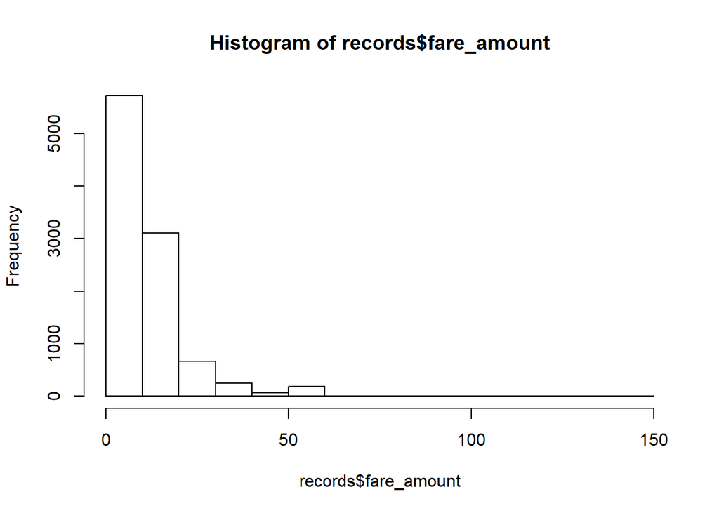

```r
hist(records$fare_amount)
```

```r
summary(as.factor(records$fare_amount))
```

```
##     6.5       7     7.5       6     5.5       8       5     8.5     4.5
##     531     524     510     505     488     459     418     404     373
##       9     9.5      10    10.5      11    11.5       4      12    12.5
##     371     355     328     323     294     252     239     233     218
##      13    13.5    14.5      14      52    15.5     3.5      15    16.5
##     199     196     176     164     160     141     133     126     121
##      16      17    17.5      18      19    19.5      21    18.5      20
##     110     108     102      82      70      69      66      59      58
##    23.5    22.5       3      23    21.5    20.5      22      26     2.5
##      46      41      40      40      38      37      37      36      35
##    24.5    25.5      30      25    29.5      24      28      29    26.5
##      34      34      33      31      30      26      25      24      23
##    28.5      27      33    27.5      32      34      36      31    31.5
##      23      22      22      20      20      18      18      15      15
##    34.5    35.5    30.5    33.5      35    32.5    37.5    38.5      37
##      15      15      14      13      13      12      11      11      10
##      38      39    40.5      40    42.5      41      45    45.5      46
##       8       8       7       6       6       5       5       5       5
##    41.5      43    36.5    39.5      42    43.5    47.5      49      50
##       4       4       3       3       3       3       3       3       3
##      57      44    46.5      48    51.5    54.5      56    57.5      58
##       3       2       2       2       2       2       2       2       2
## (Other)
##      35
```

```r
names(sort(summary(as.factor(records$fare_amount)), decreasing=T)[1])
```

```
## [1] "6.5"
```

The above is the most consistent fare. To find out what this trip is, let’s study the distance and travel time corresponding to that fare.

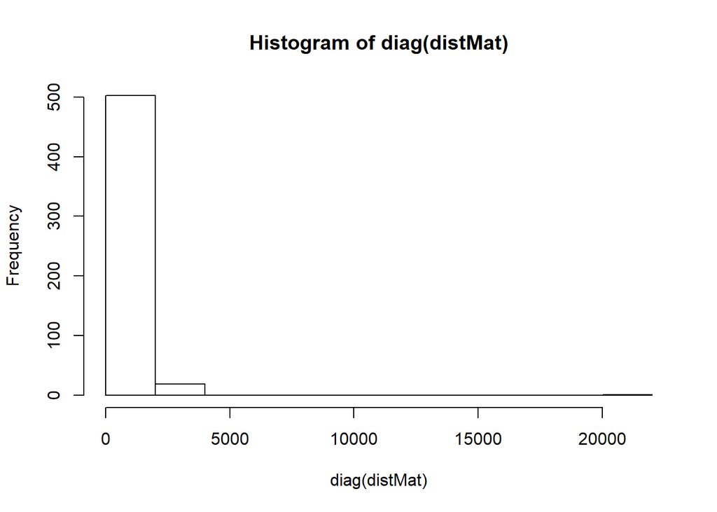

```r
consistentTime <- names(sort(summary(as.factor(records$fare_amount)), decreasing=T)[1]);
tripFare  <- data.frame(pickLat=records$pickup_latitude,pickLon=records$pickup_longitude,
                        dropLat=records$dropoff_latitude,dropLon=records$dropoff_longitude,
                        fare=records$fare_amount)
tripFare  <- tripFare[tripFare$pickLat!=0 & tripFare$pickLon!=0, ]
tripFare  <- tripFare[tripFare$dropLat!=0 & tripFare$dropLon!=0, ]
tripFare  <- tripFare[tripFare$fare==consistentTime, ]
x1 <- c(tripFare$pickLon)
y1 <- c(tripFare$pickLat)
x2 <- c(tripFare$dropLon)
y2 <- c(tripFare$dropLat)

distMat <- distm (cbind(y1,x1), cbind(y2,x2), fun = distHaversine);
hist(diag(distMat))
```

```r
summary(diag(distMat))
```

```
##    Min. 1st Qu.  Median    Mean 3rd Qu.    Max.
##     0.0   747.3  1163.0  1172.6  1493.8 20716.7
```

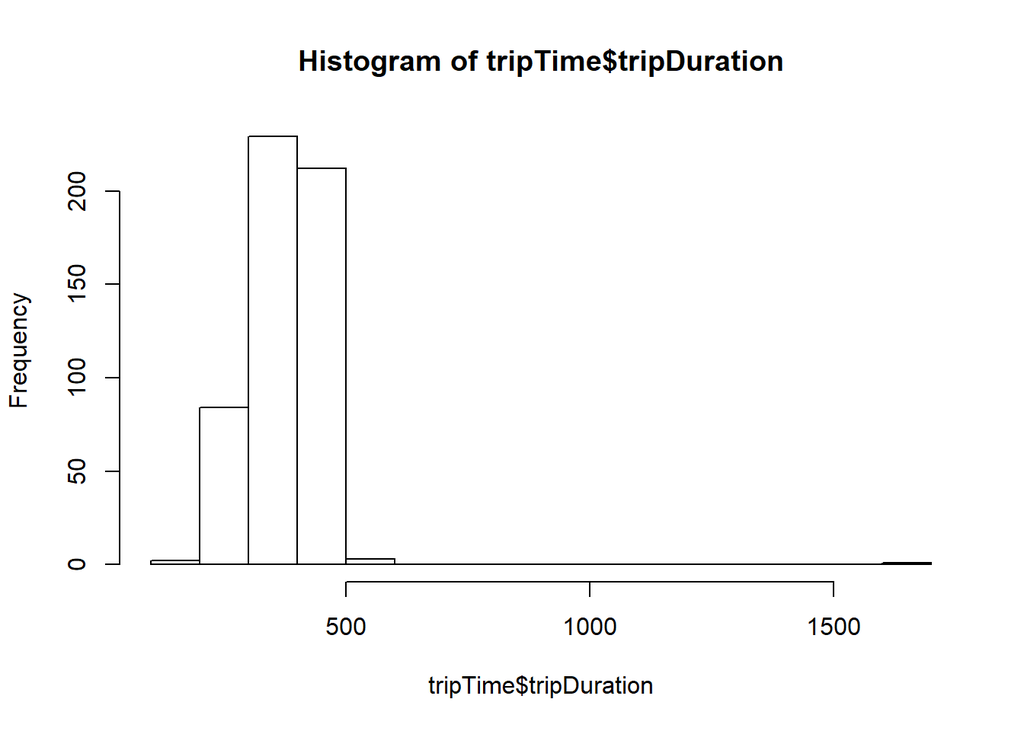

```r
tripTime <- data.frame(tripDuration=records$trip_time_in_secs, fare=records$fare_amount)
tripTime <- tripTime[tripTime$fare==consistentTime,]
hist(tripTime$tripDuration)
```

```r
summary(tripTime$tripDuration)
```

```
##    Min. 1st Qu.  Median    Mean 3rd Qu.    Max.
##   180.0   351.5   374.0   382.1   420.0  1620.0
```

As per the distributions of distance and time, this fare is for regular short trips. Mean of the distance and time has been calculated above. They are approximately 1km trips of around 6 minutes. This may be confirmed by the corresponding pickup and dropoff locations where all are within the city.

Pickup Locations

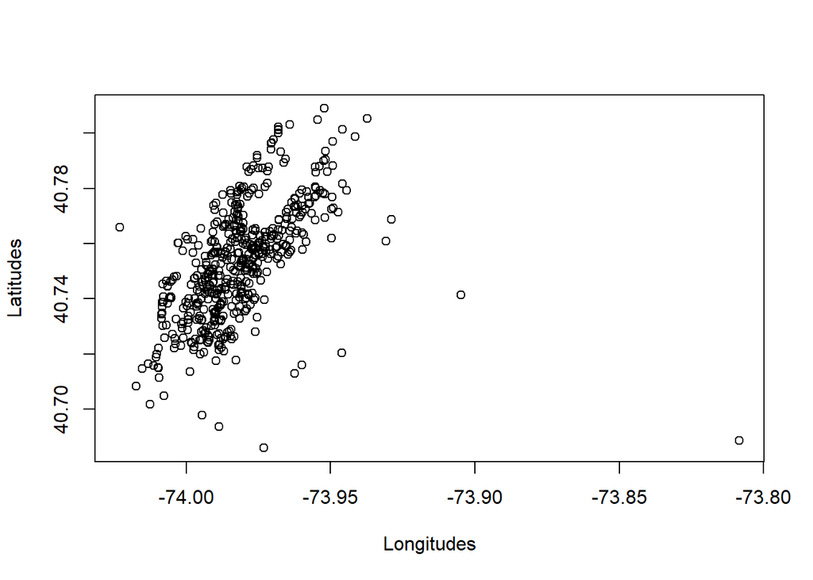

```r
gpsPickCordinates <- cbind(x1,y1)
plot(gpsPickCordinates, xlab="Longitudes", ylab="Latitudes")
```

Dropoff Locations

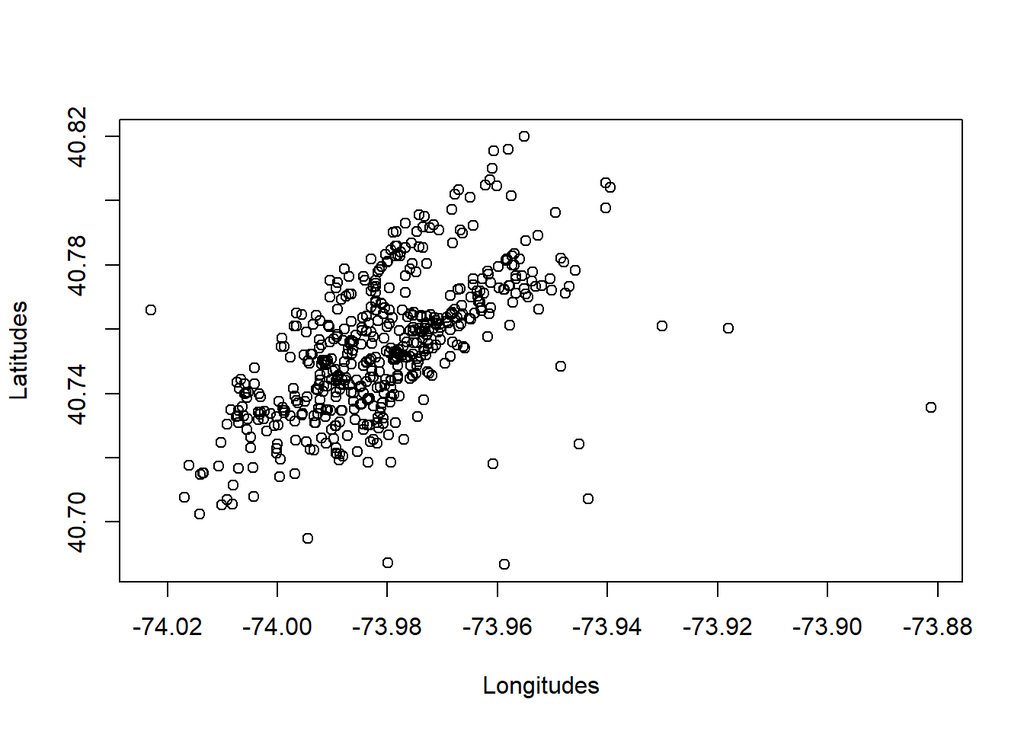

[figure not shown]

```r
gpsDropCordinates <- cbind(x2,y2)
plot(gpsDropCordinates, xlab="Longitudes", ylab="Latitudes")
```